# Lab 8 - Linear Regression in R

Sara Orofino

11/20/2018

## Part 1.

Linear Regression in R:

```r
salmon_model <- lm(salmon_fresh ~ year, data = salmon)
salmon_model
```

```
##
## Call:
## lm(formula = salmon_fresh ~ year, data = salmon)
##
## Coefficients:
## (Intercept)         year
##   -14982940         7550
```

```r
# slope of the model: y = 7550x - 14982940
```

Imports of fresh salmon (1000 pounds) = -14982940 + 7550(year)

Slope: The slope of the model indicates that for every increase year there is an increase in imports of fresh salmon of 7550 (1000 pounds).

## Part 2.

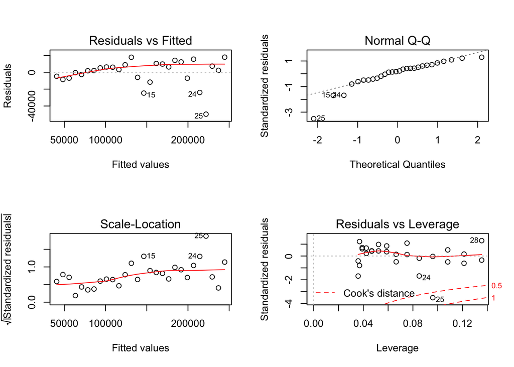

Normality: Residuals appear to be mostly normally distributed, however there are a handful of lower outliers that might be slightly skewing the data.

Heteroscedasticity: most of the values appear to fall above the line, where they should be falling in a random pattern mostly evenly about the dotted line.

Outliers: there are a handful of lower outliers that are concering, but if the measurement collection was sound, they should not be excluded.

## Part 3.

1. Does the year significanly predict salmon imports?

Yes, the model significantly predicts salmon imports p-value < 0.001.

2. What does the R<sup>2</sup> value actually mean in words?

R<sup>2</sup> = 0.9478 94.78% of the variance in fresh salmon imports is explained by this model (year).

## Part 4.

Create a finalized graph of fresh salmon imports by year.

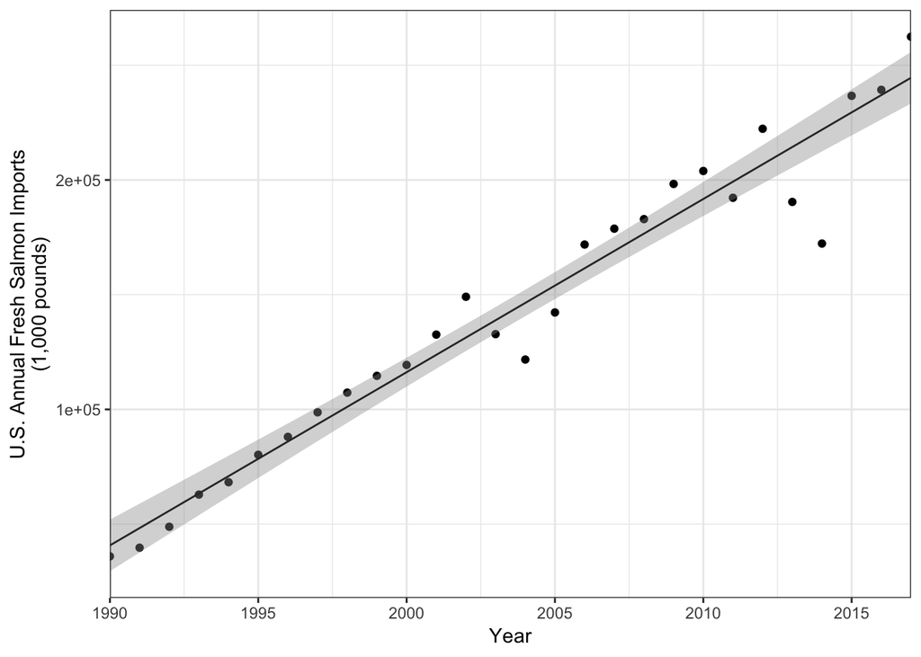

```r
salmon_final_graph <- ggplot(salmon, aes(x = year, y = salmon_fresh)) + geom_point() +
geom_smooth(method = lm, se = TRUE, size = 0.5, color = "gray20") + theme_bw() +
scale_x_continuous(expand = c(0,0), limits = c(1990, 2017)) +
labs(x = "Year", y = "U.S. Annual Fresh Salmon Imports\n(1,000 pounds)")
salmon_final_graph
```

## Part 5.

Making predictions using the model:

1. Make a data frame called new_years containing the sequence of years that we want to make predictions for. *Note: column name we create is the **SAME** as the variable name ‘year’ that the model uses*
2. Feed that data frame into the predict() function, letting it know which model to use to make prediction for the new values.

Include interval = “confidence” to also report the lower and upper bounds of the 95% CI for model fit at each year.

3. Bind the predicted outcomes (those are the values in the column ‘fit’) with the ‘new_year’ data to actually careate a useful table of predicted imports and upper and lower CI.

```r
new_years <- data.frame(year = c(2022, 2024, 2026, 2028)) #1

future_predict <- predict(salmon_model, newdata = new_years, interval = "confidence") #2
future_predict
```

```
##        fit      lwr      upr
## 1 282298.5 267877.4 296719.6
## 2 297397.6 281656.7 313138.5
## 3 312496.8 295418.5 329575.0
## 4 327595.9 309166.6 346025.2
```

```r
predictions <- data.frame(new_years, future_predict) #3
predictions
```

```
##   year      fit      lwr      upr
## 1 2022 282298.5 267877.4 296719.6
## 2 2024 297397.6 281656.7 313138.5
## 3 2026 312496.8 295418.5 329575.0
## 4 2028 327595.9 309166.6 346025.2
```

## Part 5.

Find Pearson’s R (correlation)

1. Use the cor() function to find pearson’s r for the linear relationship described between the year and fresh salmon imports.

```r
salmon_cor <- cor(salmon$year, salmon$salmon_fresh)
# output is only the pearsons r value = 0.9735387

cor.test(salmon$year, salmon$salmon_fresh)
```

```
##
##  Pearson's product-moment correlation
##
## data:  salmon$year and salmon$salmon_fresh
## t = 21.723, df = 26, p-value < 2.2e-16
## alternative hypothesis: true correlation is not equal to 0
## 95 percent confidence interval:
##  0.9429434 0.9878307
## sample estimates:
##       cor
## 0.9735387
```

2. Would you describe this as a weak/strong negative/positive correlation?

There is a strong positive correlation between year and fresh salmon imports (Pearson’s r = 0.9735).

## Part 6.

*Note: Unsure which value the b is supposed to be in the first test result output. Couldn’t find anything in her example output that matched that number.*